# Retail Superstore

# Profit has highest number of outliers and seems to incur losses too.

# Bi-Variate Analysis

```python
df.head()
```

|  | Ship Mode | Segment | Country | City | State | Postal Code | Region | Category | Sub-Category | Sales | Quantity | Discount | Profit |
| --- | --- | --- | --- | --- | --- | --- | --- | --- | --- | --- | --- | --- | --- |
| 0 | Second Class | Consumer | United States | Henderson | Kentucky | 42420 | South | Furniture | Bookcases | 261.9600 | 2 | 0.00 | 41.9136 |
| 1 | Second Class | Consumer | United States | Henderson | Kentucky | 42420 | South | Furniture | Chairs | 731.9400 | 3 | 0.00 | 219.5820 |
| 2 | Second Class | Corporate | United States | Los Angeles | California | 90036 | West | Office Supplies | Labels | 14.6200 | 2 | 0.00 | 6.8714 |
| 3 | Standard Class | Consumer | United States | Fort Lauderdale | Florida | 33311 | South | Furniture | Tables | 957.5775 | 5 | 0.45 | -383.0310 |
| 4 | Standard Class | Consumer | United States | Fort Lauderdale | Florida | 33311 | South | Office Supplies | Storage | 22.3680 | 2 | 0.20 | 2.5164 |

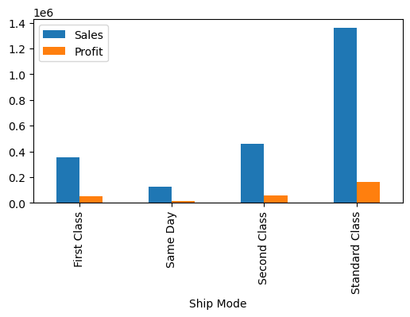

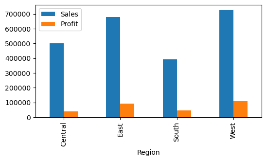

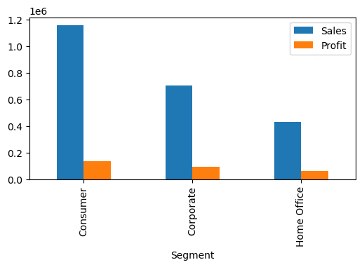

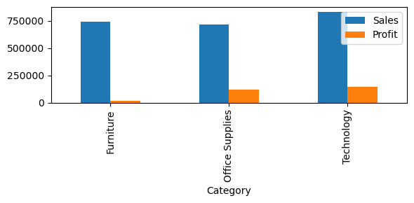

```python
pd.DataFrame(df.groupby('Ship Mode').sum()[['Sales','Profit']]).plot(kind='bar',figsize=(6,3))
pd.DataFrame(df.groupby('Region').sum()[['Sales','Profit']]).plot(kind='bar',figsize=(6,3))
pd.DataFrame(df.groupby('Segment').sum()[['Sales','Profit']]).plot(kind='bar',figsize=(6,3))
pd.DataFrame(df.groupby('Category').sum()[['Sales','Profit']]).plot(kind='bar',figsize=(6,3))
plt.tight_layout()
plt.show()
```

# OBSERVATIONS

# The profit is far less as compared to the sales that have been made through Standard Class ship mode that infers that some good amount of losses have been incurred.

# The sales are lowest from south region.

# Profits in central region are not upto the mark as compared to other regions.

# Sales and Profit both are highest for consumer segment and lowest for Home office.